# Juvenile Confocal Methods Validation

AS Huffmyer, CJ Johnson, AM Epps, JD Lemus, RD Gates

2020

## Setup

Set up workspace, set options, and load required packages.

```r
rm(list=ls(all=TRUE))
```

```r
knitr::opts_chunk$set(root.dir = "~/R",warning=FALSE, message=FALSE)
```

## Overview

To validate these metrics, we took measurements of symbiont cell counts and tissue thickness using comparative methods on a subset of juveniles from ambient temperature fed and unfed treatments. We compared these on the same juvenile corals characterized by confocal microscopy. Confocal method validations were conducted as decribed in Huffmyer et al. (2020): https://jeb.biologists.org/content/223/6/jeb220335.abstract

## Load and format dataframe

Load juvenile method validation data frame, format, and apply calibration of symbiont fluorescence by LSCM to % relative intensity, as described in Juvenile_Heterotrophy_Analysis markdown.

Nutrition: Fed or unfed treament (all from ambient temperature condition)  
Zstack: Confocal measured depth of tissue fluorescence (i.e., tissue thickness)  
Tissue: Level of measurement, all measurements applied to the whole juvenile colony  
Symbiont.Intensity: Fluorescence intensity of symbionts Tissue.Intensity: Fluorescence intensity of coral tissues  
Density: Symbiont cell density in cells per cm^2 surface area of colony  
Thickness: Tissue thickness measured on decalcified tissue tunics under dissecting microscope  
Area: Surface area of juvenile colony in cm2 Comparison: The comparison specified for that sample, either comparing symbiont cell counts to symbiont fluorescence (“cell counts”), or comparing tissue thickness on dissecting microscope to confocal measurement (“thickness”).  
Red: Calibrated symbiont fluorescence measurement to % relative intensity, as detailed in Juvenile_Heterotrophy_Analysis script and in Huffmyer et al. (2020).

```r
#load in data frame
master<-read.csv("Data/Juvenile_Confocal_Validation.csv", header=TRUE, sep=",", na.strings="NA")

#calibrate Symbiont.Intensity with Red InSpeck calibration kit as determined in Huffmyer et al. 2020
master$Red<-(master$Symbiont.Intensity+79.395) / 24.301
```

## Examine response variables

Examine response variables for normality.

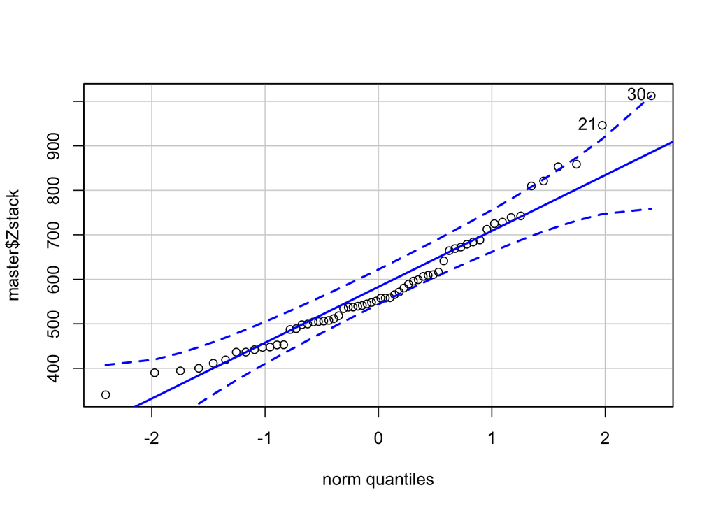

```
## [1] 30 21
```

```r
##Tissue Thickness - Confocal##
qqPlot(master$Zstack)
```

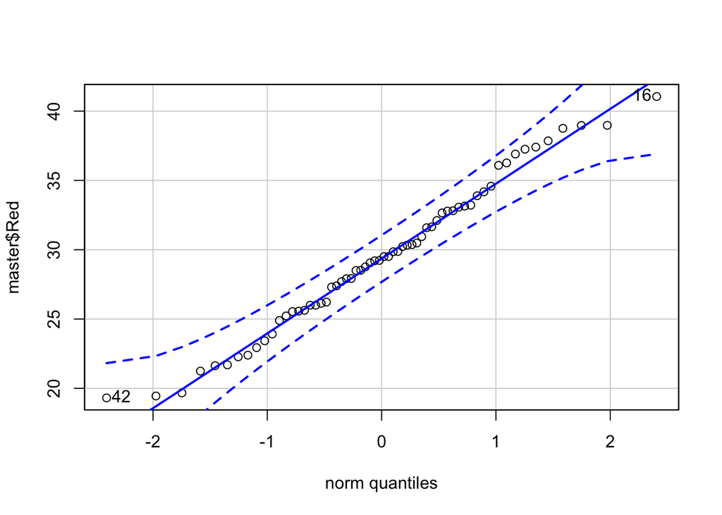

```
## [1] 16 42
```

```r
qqPlot(master$Red)
```

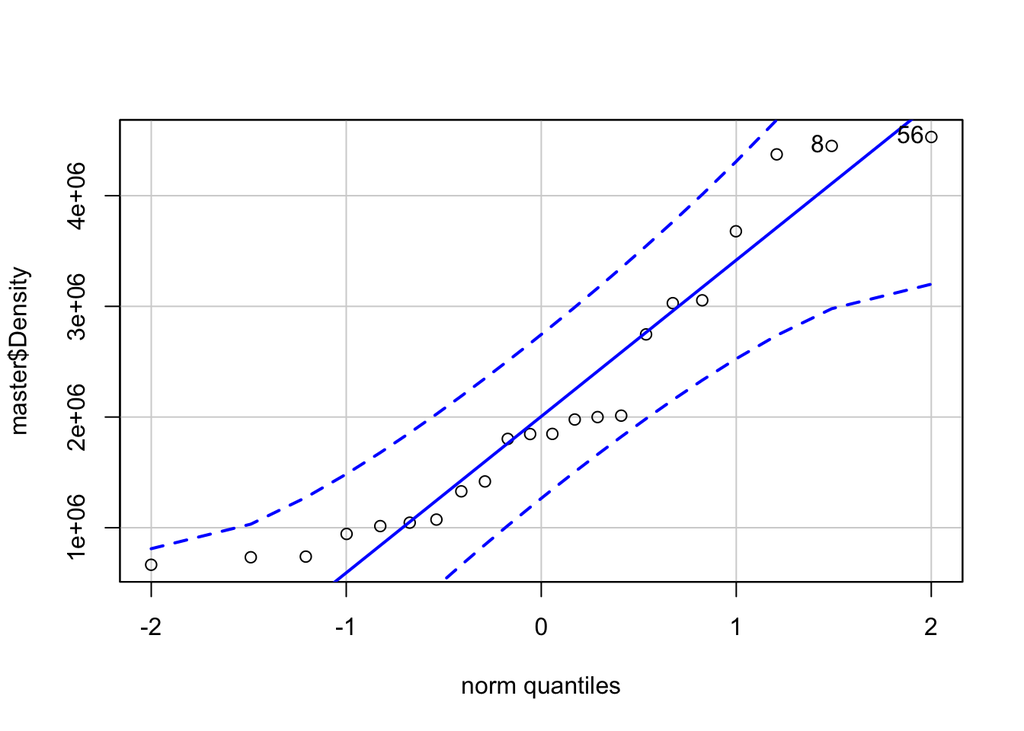

```
## [1] 56  8
```

```r
qqPlot(master$Density)
```

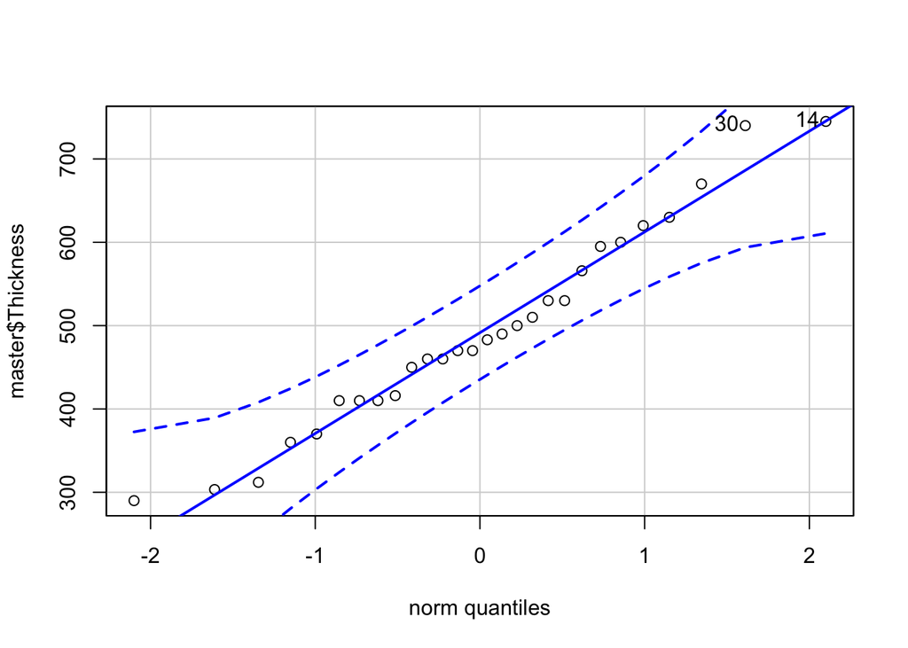

```
## [1] 14 30
```

```r
qqPlot(master$Thickness)
```

Response variables appear to be approximately normal. Next, subset data for tissue thickness comparison and for symbiont comparisons.

```r
##Subset data in master dataframe by comparison type - either Thickness or Cell counts for direct comparison of methods
compareThick<-subset(master, Comparison=="Thickness", c(Sample, Nutrition, Zstack, Tissue, Density, Thickness, Area, Comparison, Red))
compareRed<-subset(master, Comparison=="Cell Counts", c(Sample, Nutrition, Zstack, Tissue, Density, Thickness, Area, Comparison, Red))
```

## Analysis

Next, view plots of data for each metric and conduct analyses.

For each metric, analyze by:

1. One way ANOVA to analyze effect of nutrition and examine whether each metric produces the same result.
2. Correlation analyses to determine whether measurements by confocal and comparative metrics are significantly related.

### Tissue thickness

#### Plotting

Plot confocal tissue thickness data.

```r
#plot full LSCM data
Thick1 <- ddply(compareThick, c("Nutrition"), summarise,
                N    = length(Zstack[!is.na(Zstack)]),
                mean = mean(Zstack, na.rm=TRUE),
                sd   = sd(Zstack, na.rm=TRUE),
                se   = sd / sqrt(N)
); Thick1
```

```
##   Nutrition  N     mean        sd       se
## 1       Fed 13 735.0099 148.35977 41.14760
## 2     Unfed 14 488.9669  83.06437 22.19989
```

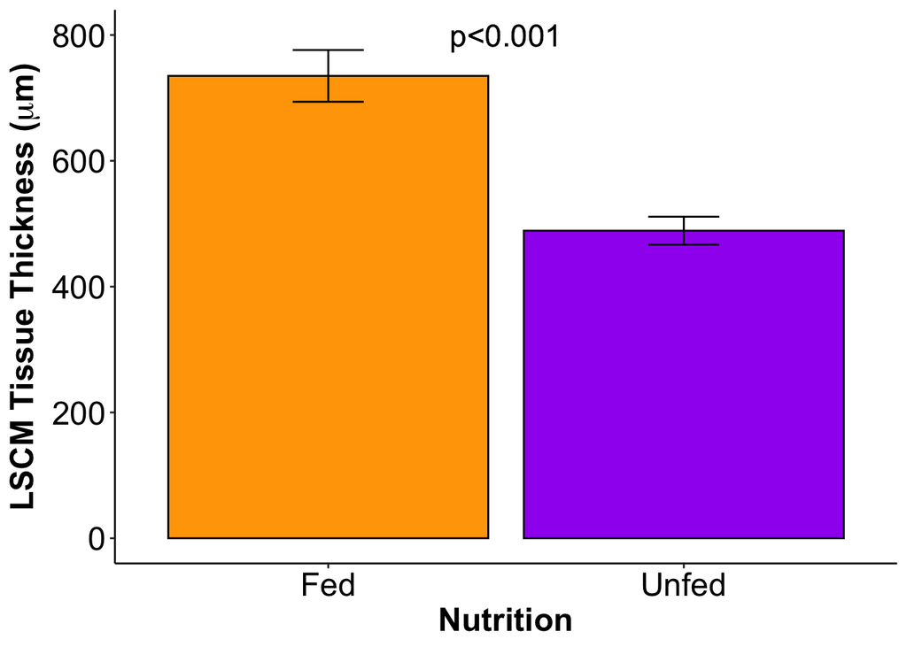

```r
#thickness as measured by LSCM Zstack
ThickConfocal_plot<-ggplot(Thick1, aes(x=Nutrition, y=mean, fill=Nutrition)) +
  geom_bar(position=position_dodge(), stat="identity", color="black") +
  scale_fill_manual(name="Nutrition",
                    values=c("orange", "purple"),
                    labels=c("Fed", "Unfed"))+
  geom_errorbar(aes(ymin=mean-se, ymax=mean+se),
                width=.2,
                position=position_dodge(.9))+
  geom_text(x=1.5, y=800, label="p<0.001", size=6, color="black") +
  theme_classic()+
  ylim(0,800)+
  theme(text = element_text(size = 18))+
  theme(axis.text = element_text(size = 18, color="black"))+
  theme(axis.title = element_text(size = 18, face="bold"))+
  theme(legend.position = "none")+
  theme(legend.text = element_text(size = 18, color="black"))+
  ylab(expression(bold(paste("LSCM Tissue Thickness ("*mu*"m)"))));ThickConfocal_plot
```

Plot tissue thickness values from measurement by dissecting microscope.

```r
#subset only by dissecting microscope
Thick2 <- ddply(compareThick, c("Nutrition"), summarise,
                N    = length(Thickness[!is.na(Thickness)]),
                mean = mean(Thickness, na.rm=TRUE),
                sd   = sd(Thickness, na.rm=TRUE),
                se   = sd / sqrt(N),
                min = min(Thickness, na.rm=TRUE),
                max = max(Thickness, na.rm=TRUE)
); Thick2
```

```
##   Nutrition  N     mean        sd       se min max
## 1       Fed 13 562.6923 112.11258 31.09444 410 745
## 2     Unfed 14 425.3690  94.52265 25.26224 290 595
```

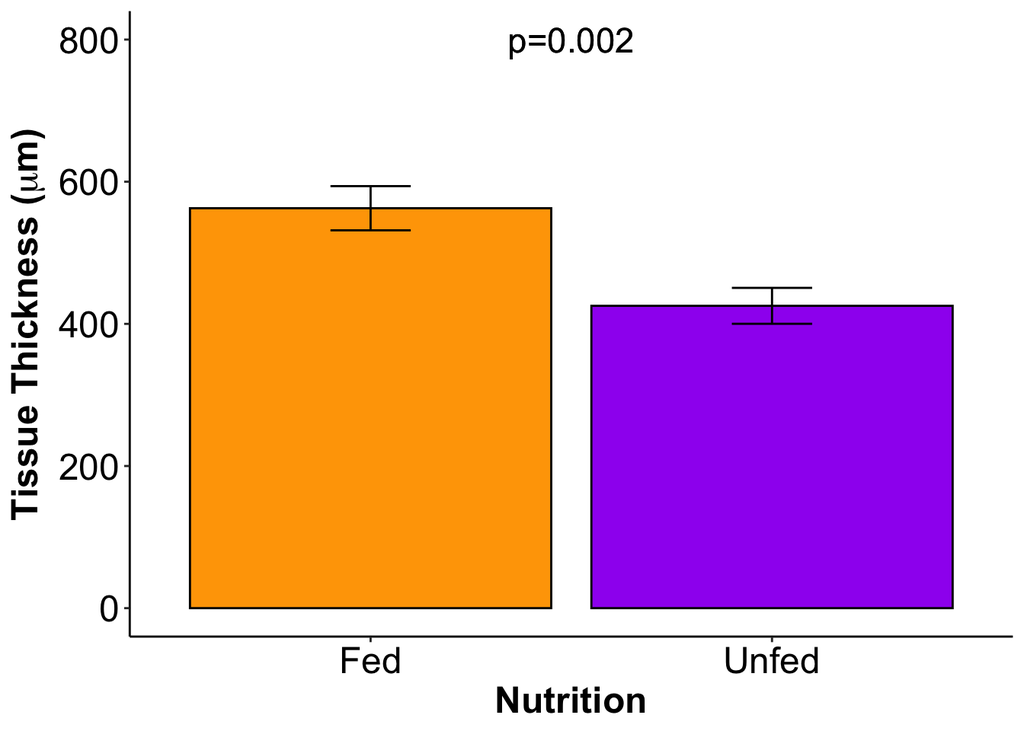

```r
ThickScope_plot<-ggplot(Thick2, aes(x=Nutrition, y=mean, fill=Nutrition)) +
  geom_bar(position=position_dodge(), stat="identity", color="black") +
  scale_fill_manual(name="Nutrition",
                    values=c("orange", "purple"),
                    labels=c("Fed", "Unfed"))+
  geom_text(x=1.5, y=800, label="p=0.002", size=6, color="black") +
  geom_errorbar(aes(ymin=mean-se, ymax=mean+se),
                width=.2,
                position=position_dodge(.9))+
  theme_classic()+
  ylim(0,800)+
  theme(text = element_text(size = 18))+
  theme(axis.text = element_text(size = 18, color="black"))+
  theme(axis.title = element_text(size = 18, face="bold"))+
  theme(legend.position = "none")+
  theme(legend.text = element_text(size = 18, color="black"))+
  ylab(expression(bold(paste("Tissue Thickness ("*mu*"m)"))));ThickScope_plot
```

#### Analysis

Analyze the effect of nutrition for each method of measurement to determine whether they produce the same result.

Dissecting microscope method:

```r
summary(aov(Thickness~Nutrition, data=compareThick))
```

```
##             Df Sum Sq Mean Sq F value Pr(>F)
## Nutrition    1 127115  127115    11.9  0.002 **
## Residuals   25 266980   10679
## ---
## Signif. codes:  0 '***' 0.001 '**' 0.01 '*' 0.05 '.' 0.1 ' ' 1
```

Confocal method:

```r
summary(aov(Zstack~Nutrition, data=compareThick))
```

```
##             Df Sum Sq Mean Sq F value   Pr(>F)
## Nutrition    1 408065  408065   28.83 1.44e-05 ***
## Residuals   25 353823   14153
## ---
## Signif. codes:  0 '***' 0.001 '**' 0.01 '*' 0.05 '.' 0.1 ' ' 1
```

Both methods produce a significant effect of nutrition and plots show that both methods indicate tissue thickness is greater in fed than unfed corals.

For both fed and unfed corals, the mean tissue thickness was higher using the confocal method (~100um difference). This may be due to the cutting process “squishing” the tunics for dissection scope analysis or the confocal may be more sensitive to capturing fluorescence “glow” that increases the appearance of depth of fluorescence.

#### Correlation of methods

Next, test for a correlation between methods.

```r
##correlation between lsm and reticle measurements for thickness
cor.test(compareThick$Thickness, compareThick$Zstack, method=c("pearson"))
```

```
##
##  Pearson's product-moment correlation
##
## data:  compareThick$Thickness and compareThick$Zstack
## t = 3.5845, df = 25, p-value = 0.001428
## alternative hypothesis: true correlation is not equal to 0
## 95 percent confidence interval:
##  0.2602484 0.7881491
## sample estimates:
##       cor
## 0.5826404
```

There is a significant correlation between the two methods.

Plot this relationship.

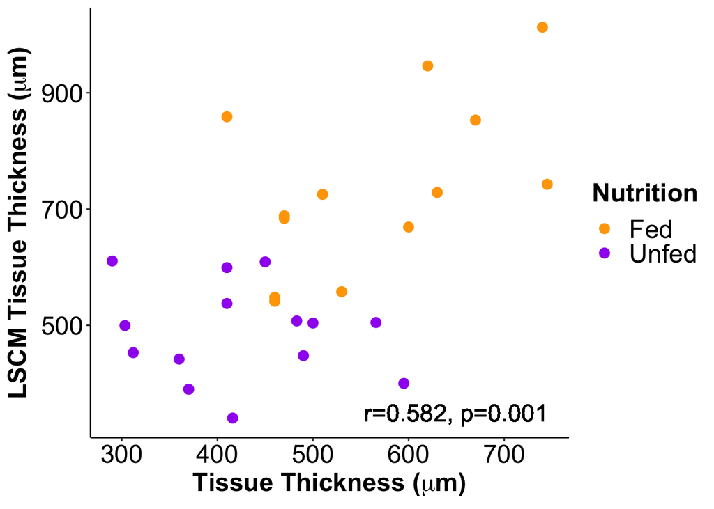

```r
ThickCorr<-ggplot(compareThick, aes(x=Thickness, y=Zstack, color=Nutrition)) +
  geom_point(size=3) +
  scale_color_manual(name="Nutrition",
                    values=c("orange", "purple"),
                    labels=c("Fed", "Unfed"))+
  theme_classic()+
  theme(text = element_text(size = 18))+
  geom_text(x=650, y=350, label="r=0.582, p=0.001", size=6, color="black") +
  theme(axis.text = element_text(size = 18, color="black"))+
  theme(axis.title = element_text(size = 18, face="bold"))+
  theme(legend.title = element_text(size = 18, face="bold"))+
  theme(legend.text = element_text(size = 18, color="black"))+
  ylab(expression(bold(paste("LSCM Tissue Thickness ("*mu*"m)")))) +
  xlab(expression(bold(paste("Tissue Thickness ("*mu*"m)")))); ThickCorr
```

Compare the coefficient of variance between the two methods. Variation is similar between scope (25%) and confocal (28%).

```r
#calculate coefficient of variance between samples
sd(compareThick$Thickness)/mean(compareThick$Thickness)
```

```
## [1] 0.250496
```

```r
#for scope method, 25% CV

sd(compareThick$Zstack)/mean(compareThick$Zstack)
```

```
## [1] 0.2818132
```

```r
#for LSCM, 28% CV
```

### Symbiont cell counts and fluorescence

#### Plotting

Plot confocal symbiont fluorescence data.

```r
#plot LSCM data
Red1 <- ddply(compareRed, c("Nutrition"), summarise,
                N    = length(Red[!is.na(Red)]),
                mean = mean(Red, na.rm=TRUE),
                sd   = sd(Red, na.rm=TRUE),
                se   = sd / sqrt(N)
); Red1
```

```
##   Nutrition  N     mean       sd        se
## 1       Fed 11 34.01217 3.729221 1.1244024
## 2     Unfed 11 25.05466 1.776805 0.5357268
```

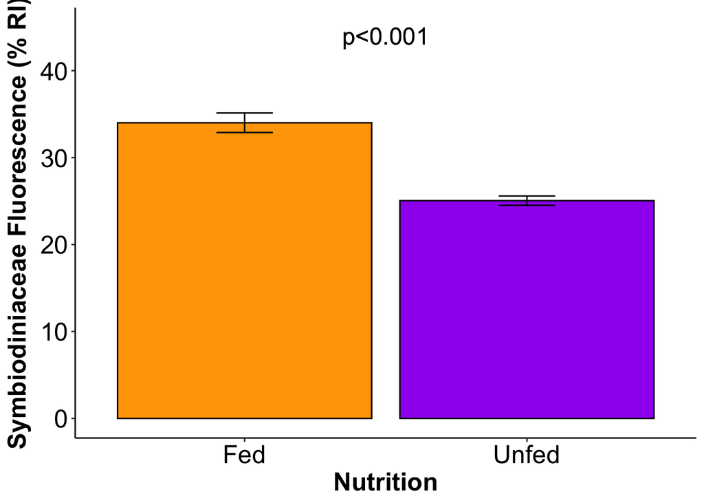

```r
#symbiont fluorescence as measured by LSCM Red
RedConfocal_plot<-ggplot(Red1, aes(x=Nutrition, y=mean, fill=Nutrition)) +
  geom_bar(position=position_dodge(), stat="identity", color="black") +
  scale_fill_manual(name="Nutrition",
                    values=c("orange", "purple"),
                    labels=c("Fed", "Unfed"))+
  geom_errorbar(aes(ymin=mean-se, ymax=mean+se),
                width=.2,
                position=position_dodge(.9))+
  geom_text(x=1.5, y=44, label="p<0.001", size=6, color="black") +
  theme_classic()+
  ylim(0,45)+
  theme(text = element_text(size = 18))+
  theme(axis.text = element_text(size = 18, color="black"))+
  theme(axis.title = element_text(size = 18, face="bold"))+
  theme(legend.position = "none")+
  theme(legend.text = element_text(size = 18, color="black"))+
  ylab(expression(bold(paste("Symbiodiniaceae Fluorescence (% RI)"))));RedConfocal_plot
```

Plot symbiont cell density values from measurement by hemocytometer.

```r
#subset only by dissecting microscope
Cells1 <- ddply(compareRed, c("Nutrition"), summarise,
                N    = length(Density[!is.na(Density)]),
                mean = mean(Density, na.rm=TRUE),
                sd   = sd(Density, na.rm=TRUE),
                se   = sd / sqrt(N),
                min = min(Density, na.rm=TRUE),
                max = max(Density, na.rm=TRUE)
); Cells1
```

```
##   Nutrition  N    mean      sd       se      min     max
## 1       Fed 11 2653156 1203372 362830.3 943826.2 4449224
## 2     Unfed 11 1556777 1093145 329595.7 665309.4 4530070
```

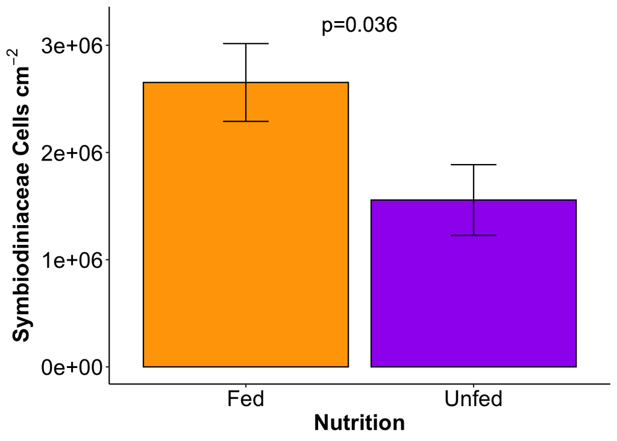

```r
Cells_plot<-ggplot(Cells1, aes(x=Nutrition, y=mean, fill=Nutrition)) +
  geom_bar(position=position_dodge(), stat="identity", color="black") +
  scale_fill_manual(name="Nutrition",
                    values=c("orange", "purple"),
                    labels=c("Fed", "Unfed"))+
  geom_errorbar(aes(ymin=mean-se, ymax=mean+se),
                width=.2,
                position=position_dodge(.9))+
  geom_text(x=1.5, y=3200000, label="p=0.036", size=6, color="black") +
  theme_classic()+
  ylim(0,3200000)+
  theme(text = element_text(size = 18))+
  theme(axis.text = element_text(size = 18, color="black"))+
  theme(axis.title = element_text(size = 18, face="bold"))+
  theme(legend.position = "none")+
  theme(legend.text = element_text(size = 18, color="black"))+
  ylab(expression(bold(paste("Symbiodiniaceae Cells cm"^-2))));Cells_plot
```

#### Analysis

Analyze the effect of nutrition for each method of measurement to determine whether they produce the same result.

Hemocytometer cell density method:

```r
summary(aov(Density~Nutrition, data=compareRed))
```

```
##             Df    Sum Sq   Mean Sq F value Pr(>F)
## Nutrition    1 6.611e+12 6.611e+12   5.003 0.0369 *
## Residuals   20 2.643e+13 1.322e+12
## ---
## Signif. codes:  0 '***' 0.001 '**' 0.01 '*' 0.05 '.' 0.1 ' ' 1
```

Confocal method:

```r
summary(aov(Red~Nutrition, data=compareRed))
```

```
##             Df Sum Sq Mean Sq F value  Pr(>F)
## Nutrition    1  441.3   441.3   51.72 5.8e-07 ***
## Residuals   20  170.6     8.5
## ---
## Signif. codes:  0 '***' 0.001 '**' 0.01 '*' 0.05 '.' 0.1 ' ' 1
```

Both methods produce a significant effect of nutrition and plots show that both methods indicate symbiont metrics are greater in fed than unfed corals.

#### Correlation of methods

Next, test for a correlation between methods.

```r
##correlation between lsm and reticle measurements for thickness
cor.test(compareRed$Density, compareRed$Red, method=c("pearson"))
```

```
##
##  Pearson's product-moment correlation
##
## data:  compareRed$Density and compareRed$Red
## t = 2.131, df = 20, p-value = 0.04569
## alternative hypothesis: true correlation is not equal to 0
## 95 percent confidence interval:
##  0.01045496 0.72101152
## sample estimates:
##       cor
## 0.4301673
```

There is a significant correlation between the two methods, but there appears to be high variability.

Plot this relationship.

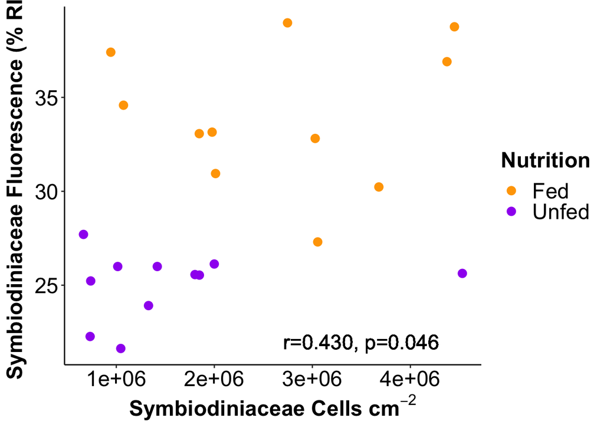

```r
RedCorr<-ggplot(compareRed, aes(x=Density, y=Red, color=Nutrition)) +
  geom_point(size=3) +
  scale_color_manual(name="Nutrition",
                    values=c("orange", "purple"),
                    labels=c("Fed", "Unfed"))+
  theme_classic()+
  theme(text = element_text(size = 18))+
  geom_text(x=3500000, y=22, label="r=0.430, p=0.046", size=6, color="black") +
  theme(axis.text = element_text(size = 18, color="black"))+
  theme(axis.title = element_text(size = 18, face="bold"))+
  theme(legend.title = element_text(size = 18, face="bold"))+
  theme(legend.text = element_text(size = 18, color="black"))+
  xlab(expression(bold(paste("Symbiodiniaceae Cells cm"^-2)))) +
  ylab(expression(bold(paste("Symbiodiniaceae Fluorescence (% RI)")))); RedCorr
```

Compare the coefficient of variance between the two methods. Variation is much higher for cell density measurements (59%) than for confocal measurements (18%). This is likely contributing to the poor correlation.

```r
#calculate coefficient of variance between samples
sd(compareRed$Red)/mean(compareRed$Red)
```

```
## [1] 0.1827818
```

```r
#for confocal method, 18% CV

sd(compareRed$Density)/mean(compareRed$Density)
```

```
## [1] 0.5959066
```

```r
#for cell counts, 60% CV
```

## Produce figure

Produce final figure.

```r
methodsfig<-plot_grid(ThickConfocal_plot, ThickScope_plot, ThickCorr, RedConfocal_plot, Cells_plot, RedCorr, labels = c("A", "B", "C", "D", "E", "F"), ncol=3, nrow=2, rel_heights= c(1,1,1, 1, 1, 1), rel_widths = c(1,1,1.5, 1, 1,1.5), label_size = 20, label_y=1, align="h")

ggsave(filename="Figures/Methods_SuppFig.png", plot=methodsfig, dpi=500, width=16, height=12, units="in")
```

[figure not shown]

Confocal method validation metrics